# Signal of the Day: The Moire Pattern

## Introduction

It may have happened for you several times, especially if you are a male: You are wearing a casual striped shirt and you decide to appear in a photo. After you look at the taken photo, you notice some weird patterns on your shirt in the photo. Look at the following image for example:

[figure not shown]

Of course there is nothing unusual with this shirt or yours. What has happened is an example of a phenomenon called the *Moirè pattern*.

## Moire by Downsampling

Moire patterns are usually best visible in images with highly repeated patterns. Consider the following photo of a brick wall for example:

[figure not shown]

Let's first read the image:

```python
import Image, ImageDraw, ImageStat
from matplotlib import pyplot as plt
import numpy as np
from PIL import Image
from PIL.ImageDraw import Draw

from io import BytesIO

from IPython.core import display
from PIL import Image


def display_pil_image(im):
   """Displayhook function for PIL Images, rendered as PNG."""

   b = BytesIO()
   im.save(b, format='png')
   data = b.getvalue()

   ip_img = display.Image(data=data, format='png', embed=True)
   return ip_img._repr_png_()


# register display func with PNG formatter:
png_formatter = get_ipython().display_formatter.formatters['image/png']
dpi = png_formatter.for_type(Image.Image, display_pil_image)

im = Image.open("brick.png")
```

If you look at the image file, you will see that the bricks are readily visible here. Now we reduce the size of the image by a factor of 2 in each dimension:

```python
im2=im.resize((im.size[0]/2,im.size[1]/2));
im2.save("brick_by2.png");
```

Still we have a decent photo. Downsampling by another factor of 2 however,

```python
im4=im2.resize((im2.size[0]/2,im2.size[1]/2));
im4.save("brick_by4.png");
```

We can now see slight Moire artifacts appearing.

Finally, we can see the high amount of Moire artifacts in the following photo, downsampled by a factor of 8 with relation to the original one:

```python
im8=im.resize((im4.size[0]/2,im4.size[1]/2));

im8.save("brick_by8.png");
```

The fact that Moire patterns appear if we down-sample the signal more than a pre-defined threshold, is a strong evidence to verify our hypothesis that this is related to sampling and the frequency domain. To make sure, let's see what happens in the Fourier domain when we down-sample the brick image.

The following code computes and shows the Fourier domain for various down-sampled versions of the brick image and the original image as well.

```
WARNING: pylab import has clobbered these variables: ['grid', 'display']
`%matplotlib` prevents importing * from pylab and numpy
```

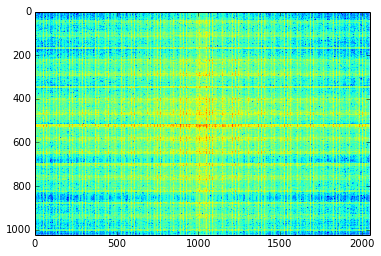

```python
%pylab inline

def fftshow(im):
    im5a=np.asarray(im);

    im5f=np.fft.fft2(im5a[:,:,0]);

    im5f[0,0]=0;

    plt.imshow(np.log(np.abs(np.fft.fftshift(im5f))),aspect='auto',interpolation='none')

def fftshow_raw(im):
    im5a=im;

    im5f=np.fft.fft2(im5a[:,:,0]);

    im5f[0,0]=0;

    plt.imshow(np.log(np.abs(np.fft.fftshift(im5f))),aspect='auto',interpolation='none')


def zero_pad(im2,im):
    zp=np.zeros(np.shape(im))

    zp[im.size[1]/2-im2.size[1]/2:im.size[1]/2+im2.size[1]/2,im.size[0]/2-im2.size[0]/2:im.size[0]/2+im2.size[0]/2,:]=np.asarray(im2)
    return zp

fftshow(im)
```

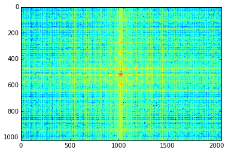

```python
fftshow_raw(zero_pad(im2,im))
```

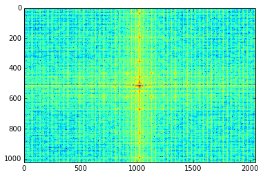

```python
fftshow_raw(zero_pad(im4,im))
```

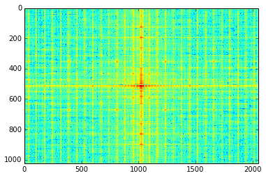

```python
fftshow_raw(zero_pad(im8,im))
```

Please note that we remove the DC component of the Fourier transform for visualization reasons.

What can we infer from the plots above? Those perpendicular lines that you see in the midlle of the frequncy plot, correspond to horizontal and vertical patterns of bricks in the originl image. In simpler terms, lines in the frequency spectrum (i.e. the frequency image) correspond to repetition frequency of bricks in the image (in either horizontal or vertical direction). In a way similar to the 1D Fourier transform, here each point in the frequency image corresponds to a sinusoidal pattern with a specific orientation. Adding up these sinusoidals reconstructs the original image.

We can see in the images above that there are high-frequency components in the image. When downsampling the image, these frequencies cause aliasing and aliasing causes Moire patterns. Mixing of these frequencies with lower-frequency components makes the Moire patterns appear.

Concluded from the above statement, we can come across a way to eliminate the Moire effect by first applying a low-pass filter to the image. This is indeed what is called *anti-aliasing* in the imaging literature. Please note that filtering should be applied before downsampling, otherwise it will be useless. Let's see how anti-aliasing works in action:

```python
im9=im.resize((im4.size[0]/2,im4.size[1]/2),Image.ANTIALIAS);

im9.save("brick_by8_antialiased.png");
```

You can see in the output that the Moire artifacts are gone.

## Generating Moire Patterns

Now let's see more closely how to create a Moire pattern. We first form a simple image containing a periodic set of stripes (similar to a pulse train in 1D) with period $p$:

```python
def bars(L,p,width):
    bar=np.zeros((L,L,3),'uint8')
    for i in np.arange(0,L):
        for j in np.arange(p,L-p,p):
            for k in np.arange(j,j+width):
                bar[i,k]=(255,255,255);
    return Image.fromarray(bar);

imma=bars(1024,16,1);

imma.save('bars1.jpg')
```

Open the file `bars1.jpg` and look at the patterns. We create also a second image, with a period $p \leq q \leq 2p$:

```python
immb=bars(1024,20,1);
immb.save('bars2.jpg')
```

Now, combining the two patterns by superimposing them, we see a new pattern (the Moire effect):

```python
immc=Image.blend(imma,immb,0.5);

immc.save('bars_overlaid.jpg')
```

Now, we rotate one of the patterns and superimpose them to see what happens:

```python
immd5=immb.rotate(5);

imme5=Image.blend(imma,immd5,0.5);


immd5.save('bars_rotated_5.jpg');
imme5.save('bars_overlaid_5.jpg');
```

You can see the appeared diamond-shaped patterns. We can easily show that the side of each diamond equals $\frac{p}{\sin\alpha}$ where $p$ is the smaller period and $\alpha$ is the rotation angle.

More serious Moire patterns appear at smaller rotation angles. Let's verify this:

```python
immd10=immb.rotate(10);

imme10=Image.blend(imma,immd10,0.5);


immd10.save('bars_rotated_10.jpg');
imme10.save('bars_overlaid_10.jpg');
```

```python
immd25=immb.rotate(25);

imme25=Image.blend(imma,immd25,0.5);


immd25.save('bars_rotated_25.jpg');
imme25.save('bars_overlaid_25.jpg');
```

```python
immd45=immb.rotate(45);

imme45=Image.blend(imma,immd45,0.5);


immd45.save('bars_rotated_45.jpg');
imme45.save('bars_overlaid_45.jpg');
```

## Overlaying in the Frequency Domain

Now let's see what happens in the frequency domain. Please note that by *overlaying* here what we mean is the multiplication of the two images.

We know from theory that rotation in the image plane causes rotation in the frequency plane. Let's verify this first:

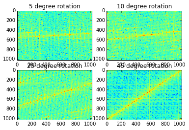

```python
subplot(221)
fftshow(immd5)
title('5 degree rotation')

subplot(222)
fftshow(immd10)
title('10 degree rotation')

subplot(223)
fftshow(immd25)
title('25 degree rotation')

subplot(224)
fftshow(immd45)
title('45 degree rotation')
```

You can see again in the above plots that lines in the frequency plane correspond to periodic patterns of lines in the image plane.

Then, we try to figure out how overlaying affects the frequency plane:

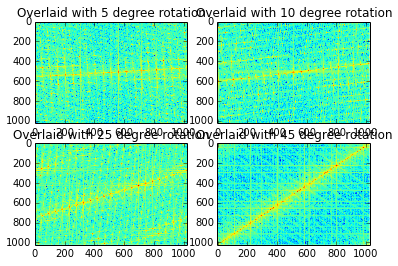

```python
subplot(221)
fftshow(imme5)
title('Overlaid with 5 degree rotation')

subplot(222)
fftshow(imme10)
title('Overlaid with 10 degree rotation')

subplot(223)
fftshow(imme25)
title('Overlaid with 25 degree rotation')

subplot(224)
fftshow(imme45)
title('Overlaid with 45 degree rotation')
```

What happens is that superimposition which causes convolution in the frequency domain, hence introducing new frequencies.

## Moire Patterns in Printing

Moire patterns have applications in the printing industry as well. In many printing systems, all what we can do is monochrome printing, that is printing either a white pixel or a black one, though with a very high resolution. One approach to create the effect of gradients using only two colors is by using the so-called "Half-tone imaging".

In halftone imaging, screens containing patterns of dots are overlaid on top of each other in order to reproduce multiple gray levels and colors. The effect is percieved as such due to the low-pass nature of the human eye.

Let's try to do so now. We first create a grid of dot patterns and a rotated copy of it:

```python
def grid(L,spacing,R):
    grid=np.ones((L,L,3),'uint8')*255
    for i in np.arange(spacing,L-spacing,spacing):
        for j in np.arange(spacing,L-spacing,spacing):
            for k in np.arange(i-R,i+R):
                for l in np.arange(j-R,j+R):
                    if np.sqrt((k-i)**2+(l-j)**2)<=R:
                        grid[k,l]=(0,0,0);
    return Image.fromarray(grid)

grid_fixed=grid(1024,8,3);


grid_rotated=grid_fixed.rotate(15);

grid_fixed.save('grid_fixed.jpg')

grid_rotated.save('grid_rotated.jpg')
```

We then overlay the two patterns and see the results:

```python
pattern=Image.blend(grid_fixed,grid_rotated,0.5);

pattern.save('rosette.jpg')
```

The patterns you can see in the above image are called *Rosettes* and are widely known in the printing industry.

If you look carefully from close distance to images printed on a newspaper for example, you can distinguish Rosette patterns. This is because newspapers are usually printed using half-tone imaging.

The following code creates a half-tone effect on an image: (Code borrowed from [here](https://github.com/philgyford/python-halftone))

```python
def gcr(im, percentage):
    '''basic "Gray Component Replacement" function. Returns a CMYK image with
       percentage gray component removed from the CMY channels and put in the
       K channel, ie. for percentage=100, (41, 100, 255, 0) >> (0, 59, 214, 41)'''
    cmyk_im = im.convert('CMYK')
    if not percentage:
        return cmyk_im
    cmyk_im = cmyk_im.split()
    cmyk = []
    for i in xrange(4):
        cmyk.append(cmyk_im[i].load())
    for x in xrange(im.size[0]):
        for y in xrange(im.size[1]):
            gray = min(cmyk[0][x,y], cmyk[1][x,y], cmyk[2][x,y]) * percentage / 100
            for i in xrange(3):
                cmyk[i][x,y] = cmyk[i][x,y] - gray
            cmyk[3][x,y] = gray
    return Image.merge('CMYK', cmyk_im)

def halftone(im, cmyk, sample, scale):
    '''Returns list of half-tone images for cmyk image. sample (pixels),
       determines the sample box size from the original image. The maximum
       output dot diameter is given by sample * scale (which is also the number
       of possible dot sizes). So sample=1 will presevere the original image
       resolution, but scale must be >1 to allow variation in dot size.'''
    cmyk = cmyk.split()
    dots = []
    angle = 0
    for channel in cmyk:
        channel = channel.rotate(angle, expand=1)
        size = channel.size[0]*scale, channel.size[1]*scale
        half_tone = Image.new('L', size)
        draw = ImageDraw.Draw(half_tone)
        for x in xrange(0, channel.size[0], sample):
            for y in xrange(0, channel.size[1], sample):
                box = channel.crop((x, y, x + sample, y + sample))
                stat = ImageStat.Stat(box)
                diameter = (stat.mean[0] / 255)**0.5
                edge = 0.5*(1-diameter)
                x_pos, y_pos = (x+edge)*scale, (y+edge)*scale
                box_edge = sample*diameter*scale
                draw.ellipse((x_pos, y_pos, x_pos + box_edge, y_pos + box_edge), fill=255)
        half_tone = half_tone.rotate(-angle, expand=1)
        width_half, height_half = half_tone.size
        xx=(width_half-im.size[0]*scale) / 2
        yy=(height_half-im.size[1]*scale) / 2
        half_tone = half_tone.crop((xx, yy, xx + im.size[0]*scale, yy + im.size[1]*scale))
        dots.append(half_tone)
        angle += 15
    return dots


im = Image.open("lena.png")

cmyk = gcr(im, 0)
dots = halftone(im, cmyk, 5, 10)
newsp = Image.merge('CMYK', dots)
```

Finally, we save the output image:

```python
newsp.convert('RGB').save('lena_out.png')
```

If you look at the generated image from far enough distance, you will see what you'd expect from a newspaper.

When you want to scan a photo from a newspaper, the rosette patterns become more obvious and hence undersiable. To reduce their effect, one simplest way is to use a low-pass filter, which we already know quite well about.